# Sortino Shiny Write up

For the histogram tab, the user sees this:

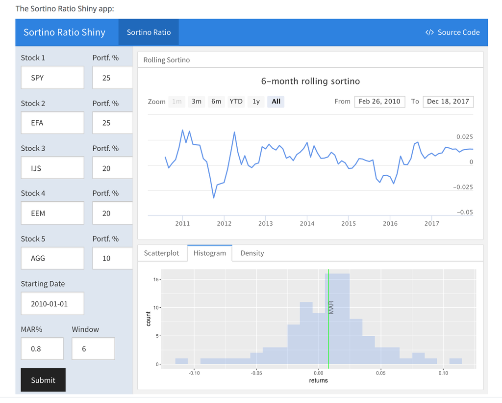

Here is the histogram code chunk.

```r
renderPlot({
  validate(need(input$go != 0, "Please choose your portfolio assets, weights, MAR, rolling window and start date and click submit."))
  MAR <- mar()
  portfolio_returns_tq_rebalanced_monthly <- portfolio_returns_tq_rebalanced_monthly()

  portfolio_returns_tq_rebalanced_monthly %>%
    ggplot(aes(x = returns)) +
    geom_histogram(alpha = 0.25, binwidth = .01, fill = "cornflowerblue") +
    geom_vline(xintercept = MAR, color = "green") +
    annotate(geom = "text", x = MAR,
             y = 10, label = "MAR", fontface = "plain",
             angle = 90, alpha = .5, vjust =  1)
})
```

And finally for the density tab, the user sees this:

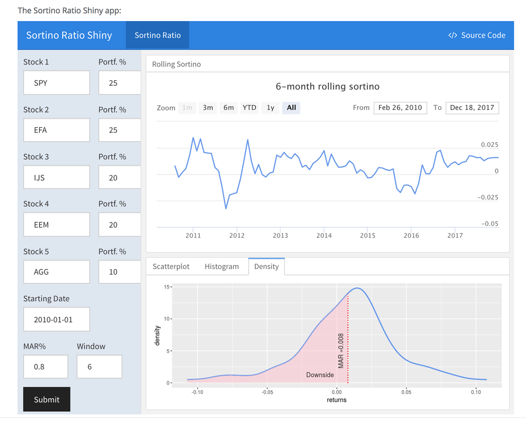

Here is the density chart code chunk.

```r
renderPlot({
  validate(need(input$go != 0, "Please choose your portfolio assets, weights, MAR, rolling window and start date and click submit."))
  MAR <- mar()
  portfolio_returns_tq_rebalanced_monthly <- portfolio_returns_tq_rebalanced_monthly()

  sortino_density_plot <- portfolio_returns_tq_rebalanced_monthly %>%
    ggplot(aes(x = returns)) +
    stat_density(geom = "line", size = 1, color = "cornflowerblue")

  shaded_area_data <- ggplot_build(sortino_density_plot)$data[[1]] %>%
    filter(x < MAR)

  sortino_density_plot +
  geom_area(data = shaded_area_data, aes(x = x, y = y), fill="pink", alpha = 0.5) +
  geom_segment(data = shaded_area_data, aes(x = MAR, y = 0, xend = MAR, yend = y),
               color = "red", linetype = "dotted") +
  annotate(geom = "text", x = MAR, y = 5, label = paste("MAR =", MAR, sep = ""),
           fontface = "plain", angle = 90, alpha = .8, vjust =  -1) +
  annotate(geom = "text", x = (MAR - .02), y = .1, label = "Downside",
           fontface = "plain", alpha = .8, vjust =  -1)

})
```

Have a quick look at the three previous chunks and notice the use of `validate(need(input$go != 0, "Please choose your portfolio assets, weights, MAR, rolling window and start date and click submit."))`. This is so when the user first opens the app and the submit button has not been activated, the user sees something besides white space.

That completes our project on the Sortino Ratio. We didn’t introduce any new functions or calculations in the Shiny app. We gave users a mechanism for building their own portfolios and time frames and passing them to the functions and visualizations that we already tested in our previous work. That was by design. The previous posts were meant to be a sandbox or a playground or whatever kindergarten-themed analogy signifies a place to experiment. The Shiny app’s goal is to make that experimental work accessible to a broad audience of end users.

Thanks for reading and happy Shiny app’ing!